# PPCA0026 - Tarefa de Casa: Teoria da Decisão Bayesiana na Prática

Aplicando os Conceitos da Semana 5

Author

Denard Costa Soares

Published

July 11, 2025

**Prazo de Entrega:** 2025-07-20 23:59

## Introdução

Nesta tarefa, você aprofundará seu conhecimento sobre o Framework de Decisão Bayesiana. O objetivo é ir além da introdução vista em aula e aplicar o framework completo para tomar decisões ótimas sob incerteza, tanto com crenças a priori quanto com crenças atualizadas por dados (a posteriori).

**Instruções Gerais:**

- Este arquivo serve como seu template de resposta. Preencha as seções marcadas com seu código R, as saídas geradas, e suas análises textuais.
- **Entrega:** Envie dois arquivos: este `.qmd` completo e o arquivo `.html` auto-contido resultante.

## Problema 1: Decisão Ótima com Priori e Custos Discretos

Neste problema, você atuará como um consultor para uma empresa farmacêutica, usando a teoria da decisão para recomendar uma estratégia para o lançamento de um novo medicamento.

### Cenário

Uma empresa está testando um novo medicamento. A decisão a ser tomada é se deve **“Lançar”** o medicamento com base nos resultados de um ensaio clínico ou **“Não Lançar”**.

- **Hipótese Nula ($H_0$)**: O medicamento não tem efeito (a diferença média de melhora, `d`, é 0).
- **Hipótese Alternativa ($H_1$)**: O medicamento tem um efeito ($d > 0$).
- **Custos dos Erros**:
  - **Erro Tipo I (Falso Positivo):** Lançar um medicamento ineficaz. O custo ($C_I$) é de **$1,000,000**.
  - **Erro Tipo II (Falso Negativo):** Não lançar um medicamento que é eficaz. O custo ($C_{II}$) depende do tamanho do efeito perdido. A empresa estima que $C_{II}(d) = d \times \$10,000,000$.
- **Crença a Priori**: Antes do ensaio clínico final, a diretoria acredita que há **50% de chance de o medicamento não ter efeito** ($P(d=0) = 0.5$). Se ele tiver um efeito, eles acreditam que as probabilidades são: 50% de chance de ser um efeito “pequeno” ($d=0.2$), 30% de ser “médio” ($d=0.5$), e 20% de ser “grande” ($d=1.0$).
- **O Ensaio Clínico**: O ensaio será realizado com `n=50` pacientes por grupo e $\sigma=1$.

### Parte A: A Decisão a Priori

#### 1. Calcule as Probabilidades a Priori

```r
# Carregue os pacotes necessários
library(tidyverse)
library(knitr)
# A probabilidade de H0 (d=0) é 0.5
p_d0 <- 0.5

# As probabilidades condicionais de d > 0 somam 1 (50% + 30% + 20%)
# A probabilidade total de d > 0 é 1 - p_d0 = 0.5
# As probabilidades a priori incondicionais são:
p_d_pequeno <- 0.5 * 0.50 # P(d>0) * P(d=0.2 | d>0)
p_d_medio   <- 0.5 * 0.30 # P(d>0) * P(d=0.5 | d>0)
p_d_grande  <- 0.5 * 0.20 # P(d>0) * P(d=1.0 | d>0)

# Armazene-as em um data frame
priors_df <- tibble(
  estado_mundo = c("Nenhum Efeito (d=0)", "Efeito Pequeno (d=0.2)", "Efeito Médio (d=0.5)", "Efeito Grande (d=1.0)"),
  d = c(0, 0.2, 0.5, 1.0),
  prob_priori = c(p_d0, p_d_pequeno, p_d_medio, p_d_grande)
)

# Apresenta a tabela de probabilidades a priori
kable(priors_df,
      col.names = c("Estado do Mundo", "Valor de 'd'", "Probabilidade a Priori"),
      caption = "Probabilidades a Priori para Cada Estado do Mundo.",
      digits = 2)
```

Probabilidades a Priori para Cada Estado do Mundo.

| Estado do Mundo | Valor de ‘d’ | Probabilidade a Priori |
| --- | --- | --- |
| Nenhum Efeito (d=0) | 0.0 | 0.50 |
| Efeito Pequeno (d=0.2) | 0.2 | 0.25 |
| Efeito Médio (d=0.5) | 0.5 | 0.15 |
| Efeito Grande (d=1.0) | 1.0 | 0.10 |

**Análise da Tarefa 1.A.1:**

As probabilidades a priori para cada estado do mundo (tamanho do efeito d) foram calculadas com base nas crenças da diretoria. A probabilidade de o medicamento não ter efeito (d=0) é de 0.5. A probabilidade de ele ter algum efeito é também de 0.5, que foi distribuída entre os possíveis tamanhos de efeito (0.2, 0.5, 1.0) conforme as crenças condicionais fornecidas, resultando nas probabilidades marginais mostradas na tabela acima.

#### 2. Simule o Risco Esperado a Priori

```r
# Você precisará de uma função para calcular o poder, como a da tarefa anterior.
# Se necessário, defina-a aqui.
# Função para calcular o poder de um teste z de uma cauda
# O desvio padrão da diferença (SE) é sqrt(sigma^2/n1 + sigma^2/n2)
# Com sigma=1 e n=50 por grupo, SE = sqrt(1/50 + 1/50) = sqrt(2/50) = 0.2
SE <- sqrt(1^2/50 + 1^2/50)

calcular_poder <- function(n, d, sigma, alpha) {
  # Esta função calcula o poder para um teste z de uma cauda.
  se <- sqrt(2 * sigma^2 / n)
  z_critico <- qnorm(1 - alpha)
  poder <- pnorm(z_critico - d / se, lower.tail = FALSE)
  return(poder)
}

# Defina os parâmetros da simulação
custo_I <- 1000000 # Custo do Erro Tipo I
custo_II_func <- function(d) { d * 10000000 } # Custo do Erro Tipo II

# Adicione custos ao data frame de priors
priors_df <- priors_df %>%
  mutate(
    custo_I = ifelse(d == 0, custo_I, 0),
    custo_II = ifelse(d > 0, custo_II_func(d), 0)
  )

# Crie uma gama de valores de alpha para testar
alphas <- seq(0.01, 0.5, by = 0.01)

# Calcule o Risco Esperado para cada alpha
risco_esperado <- sapply(alphas, function(alpha) {
  # Para cada alpha, calcule o poder para cada d > 0
  poderes <- sapply(priors_df$d[priors_df$d > 0], function(d_val) {
    calcular_poder(n = 50, d = d_val, sigma = 1, alpha = alpha)
  })

  # Probabilidade de Erro Tipo II (beta) é 1 - poder
  betas <- 1 - poderes

  # Risco de Erro Tipo I
  risco_I <- priors_df$prob_priori[1] * priors_df$custo_I[1] * alpha

  # Risco de Erro Tipo II
  risco_II <- sum(priors_df$prob_priori[2:4] * priors_df$custo_II[2:4] * betas)

  # Risco Total
  risco_total <- risco_I + risco_II
  return(risco_total)
})

risco_df <- tibble(alpha = alphas, risco = risco_esperado)
```

#### 3. Encontre a Regra de Decisão Ótima

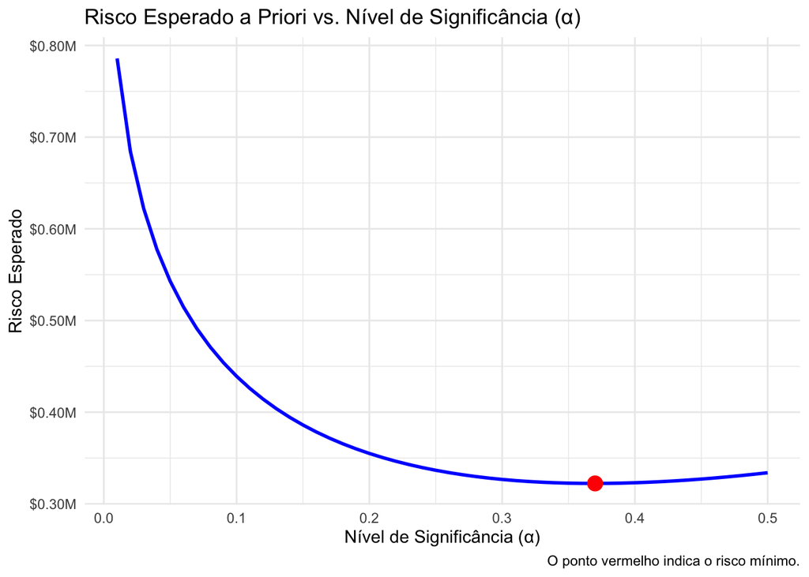

```r
# Plote o Risco Esperado vs. α
# ... seu código ggplot2 aqui ...


# Plote o Risco Esperado vs. α
ggplot(risco_df, aes(x = alpha, y = risco)) +
  geom_line(color = "blue", size = 1) +
  geom_point(data = risco_df %>% filter(risco == min(risco)), color = "red", size = 4) +
  scale_y_continuous(labels = scales::dollar_format(prefix = "$", scale = 1e-6, suffix = "M")) +
  labs(
    title = "Risco Esperado a Priori vs. Nível de Significância (α)",
    x = "Nível de Significância (α)",
    y = "Risco Esperado",
    caption = "O ponto vermelho indica o risco mínimo."
  ) +
  theme_minimal()
```

```r
# Encontre e reporte o α_ótimo e o risco mínimo correspondente
alpha_otimo <- risco_df$alpha[which.min(risco_df$risco)]
risco_minimo <- min(risco_df$risco)
print(alpha_otimo)
```

```
[1] 0.37
```

```r
print(risco_minimo)
```

```
[1] 322316.8
```

**Análise da Tarefa 1.A.3:** O ponto mais baixo da curva, destacado em vermelho, representa o equilíbrio ideal entre a regra de decisão do ensaio clínico (o nível de significância α) e o prejuízo financeiro esperado pela empresa. Este é o ponto onde o risco financeiro esperado é minimizado. A regra de decisão ótima para a empresa não é o tradicional α=0.05. Em vez disso, a análise bayesiana, que incorpora os custos e as crenças específicas da empresa, recomenda o uso de um α=0.37. Adotar este critério para o ensaio clínico é a estratégia que oferece o menor prejuízo esperado, totalizando $322.316,80. Este valor representa o custo que a empresa espera ter ao se comprometer com a estratégia de teste, antes mesmo de ver os dados.

#### 4. Tome a Decisão a Priori

```r
# Calcule o risco da estratégia "Não Lançar"
# Este é o custo esperado de cometer um Erro Tipo II, sem nunca testar
risco_nao_lancar <- sum(priors_df$prob_priori * priors_df$custo_II)

# Compare os riscos e determine a ação ótima a priori
decisao_priori <- if (risco_minimo < risco_nao_lancar) {
  decisao_final_priori <- "A ação ótima é 'Testar e Lançar se p < 0.37'."
  print(paste("Risco da Estratégia 'Testar com α_ótimo':", scales::dollar(risco_minimo)))
} else {
  decisao_final_priori <- "A ação ótima é 'Não Lançar'."
print(paste("Risco da Estratégia 'Não Lançar':", scales::dollar(risco_nao_lancar)))
}
```

```
[1] "Risco da Estratégia 'Testar com α_ótimo': $322,317"
```

```r
print(paste("Decisão a Priori:", decisao_final_priori))
```

```
[1] "Decisão a Priori: A ação ótima é 'Testar e Lançar se p < 0.37'."
```

**Análise da Tarefa 1.A.4:**

Decisão Ótima a Priori:

Ao comparar os riscos das duas estratégias, vemos que o risco de testar ($322.316,80) é significativamente menor do que o risco de simplesmente não lançar o medicamento ($2.250.000).

Portanto, a ação ótima a priori é realizar o ensaio clínico usando a regra de decisão com alpha=0.37. Embora o teste em si tenha um risco associado, ele é muito preferível à perda esperada de mais de 2 milhões de dólares que ocorreria se a empresa abandonasse um medicamento potencialmente eficaz sem investigá-lo adequadamente.

### Parte B: A Decisão a Posteriori (Atualização com Dados)

#### Cenário 1: Dados Desanimadores ($\hat{d}_1 = 0.15, SE = 0.2$)

```r
# Dados observados
d_obs_1 <- 0.15
se_obs <- 0.2

# 1. Calcule a verossimilhança para cada estado do mundo d
# A verossimilhança dos dados (d_obs) para cada possível valor de d é P(d_obs | d)
# Usamos a densidade da distribuição Normal: d_obs ~ N(d, se_obs^2)
verossimilhanca_1 <- dnorm(d_obs_1, mean = priors_df$d, sd = se_obs)

# 2. Calcule as probabilidades a posteriori
# P(d | d_obs) ∝ P(d_obs | d) * P(d)
prob_conjunta_1 <- verossimilhanca_1 * priors_df$prob_priori
# Normalizar para que a soma seja 1
prob_posteriori_1 <- prob_conjunta_1 / sum(prob_conjunta_1)

# Armazene em um data frame para análise
results_cenario1 <- priors_df %>%
  mutate(
    verossimilhanca = verossimilhanca_1,
    prob_posteriori = prob_posteriori_1
  )

# 3. Calcule o Risco Esperado a Posteriori para "Lançar" e "Não Lançar"
# Risco(Lançar | dados) = P(d=0 | dados) * Custo(Erro Tipo I)
risco_lancar_post_1 <- results_cenario1$prob_posteriori[1] * results_cenario1$custo_I[1]

# Risco(Não Lançar | dados) = Σ [P(d>0 | dados) * Custo(Erro Tipo II)]
risco_nao_lancar_post_1 <- sum(results_cenario1$prob_posteriori[2:4] * results_cenario1$custo_II[2:4])

# 4. Determine a ação ótima a posteriori
acao_otima_1 <- ifelse(risco_lancar_post_1 < risco_nao_lancar_post_1, "Lançar", "Não Lançar")

kable(results_cenario1 %>% select(estado_mundo, prob_priori, prob_posteriori),
      col.names = c("Estado do Mundo", "Prob. a Priori", "Prob. a Posteriori"),
      caption = "Atualização das Crenças no Cenário 1.",
      digits = 4)
```

Atualização das Crenças no Cenário 1.

| Estado do Mundo | Prob. a Priori | Prob. a Posteriori |
| --- | --- | --- |
| Nenhum Efeito (d=0) | 0.50 | 0.5787 |
| Efeito Pequeno (d=0.2) | 0.25 | 0.3715 |
| Efeito Médio (d=0.5) | 0.15 | 0.0497 |
| Efeito Grande (d=1.0) | 0.10 | 0.0000 |

```r
print(paste("Risco da Estratégia 'Lançar':", scales::dollar(risco_lancar_post_1)))
```

```
[1] "Risco da Estratégia 'Lançar': $578,705"
```

```r
print(paste("Risco da Estratégia 'Não Lançar':", scales::dollar(risco_nao_lancar_post_1)))
```

```
[1] "Risco da Estratégia 'Não Lançar': $991,958"
```

```r
print(acao_otima_1)
```

```
[1] "Lançar"
```

**Análise do Cenário 1:**

A ação ótima é aquela que minimiza o risco esperado. Comparando os dois valores, o risco de “Lançar” ($578.705) é significativamente menor do que o risco de “Não Lançar” ($991.958). Portanto, a ação ótima a posteriori é Lançar o medicamento.

Os efeitos dos dados “desanimadores” foi o reforço na incerteza, pois os dados fortaleceram a crença de que o medicamento provavelmente não tem um efeito grande, aumentando a probabilidade de um efeito nulo ou pequeno, e não inverteram a decisão. Apesar do aumento na probabilidade de o medicamento ser ineficaz (P(d=0) = 0.58), o custo associado a esse erro (Risco de Lançar = $578.705) ainda é menor do que o custo de oportunidade de não lançar um medicamento que, segundo as novas crenças, ainda tem uma chance considerável de ter um efeito pequeno ou médio (Risco de Não Lançar = $991.958).

Em suma, os dados enfraqueceram o otimismo sobre o medicamento, mas não a ponto de tornar o abandono a melhor opção financeira. O alto custo de oportunidade de perder um medicamento eficaz ainda supera o risco de lançar um produto ineficaz, mesmo quando a probabilidade deste último aumentou.

#### Cenário 2: Dados Promissores ($\hat{d}_2 = 0.60, SE = 0.2$)

```r
# Repita os passos 1-4 para o Cenário 2
# Dados observados
d_obs_2 <- 0.60

# 1. Calcule a verossimilhança
verossimilhanca_2 <- dnorm(d_obs_2, mean = priors_df$d, sd = se_obs)

# 2. Calcule as probabilidades a posteriori
prob_conjunta_2 <- verossimilhanca_2 * priors_df$prob_priori
prob_posteriori_2 <- prob_conjunta_2 / sum(prob_conjunta_2)

results_cenario2 <- priors_df %>%
  mutate(
    verossimilhanca = verossimilhanca_2,
    prob_posteriori = prob_posteriori_2
  )

# 3. Calcule o Risco Esperado a Posteriori
risco_lancar_post_2 <- results_cenario2$prob_posteriori[1] * results_cenario2$custo_I[1]
risco_nao_lancar_post_2 <- sum(results_cenario2$prob_posteriori[2:4] * results_cenario2$custo_II[2:4])

kable(results_cenario2 %>% select(estado_mundo, prob_priori, prob_posteriori),
      col.names = c("Estado do Mundo", "Prob. a Priori", "Prob. a Posteriori"),
      caption = "Atualização das Crenças no Cenário 2.",
      digits = 4)
```

Atualização das Crenças no Cenário 2.

| Estado do Mundo | Prob. a Priori | Prob. a Posteriori |
| --- | --- | --- |
| Nenhum Efeito (d=0) | 0.50 | 0.0300 |
| Efeito Pequeno (d=0.2) | 0.25 | 0.1826 |
| Efeito Médio (d=0.5) | 0.15 | 0.7144 |
| Efeito Grande (d=1.0) | 0.10 | 0.0730 |

```r
# 4. Determine a ação ótima a posteriori
acao_otima_2 <- ifelse(risco_lancar_post_2 < risco_nao_lancar_post_2, "Lançar", "Não Lançar")

print(paste("Risco da Estratégia 'Lançar':", scales::dollar(risco_lancar_post_2)))
```

```
[1] "Risco da Estratégia 'Lançar': $29,976.29"
```

```r
print(paste("Risco da Estratégia 'Não Lançar':", scales::dollar(risco_nao_lancar_post_2)))
```

```
[1] "Risco da Estratégia 'Não Lançar': $4,667,526"
```

```r
print(acao_otima_2)
```

```
[1] "Lançar"
```

**Análise do Cenário 2:**

A crença de que o medicamento não tem efeito (d=0) despencou de 50% para apenas 3%.A crença em um efeito médio (d=0.5) saltou de 15% para se tornar a hipótese dominante, com 71.44% de probabilidade. O risco de “Lançar” ($29.976,29) é mais de 150 vezes menor que o risco de “Não Lançar” ($4.667.526). Portanto, a ação ótima a posteriori é, sem dúvida, Lançar o medicamento. Os dados promissores contrastaram fortemente com o cenário de dados desanimadores, com redução drástica da incerteza, pois eliminaram a crença de que o medicamento era ineficaz. A probabilidade de um Erro Tipo I (lançar um medicamento ineficaz) tornou-se muito pequena, fazendo com que o risco de “Lançar” caísse para um valor mínimo.E ao mesmo tempo, os dados criaram uma alta certeza de que o medicamento era eficaz. Isso fez com que o risco de “Não Lançar” (o custo de oportunidade de abandonar um produto de sucesso) se tornasse extremamente alto, refletindo uma perda quase certa de milhões em receita potencial. Em resumo, enquanto os dados desanimadores do Cenário 1 apenas ajustaram as probabilidades, os dados promissores do Cenário 2 provocaram uma mudança de paradigma nas crenças da empresa. Eles forneceram uma evidência forte que reforçou a decisão de prosseguir, tornando a escolha de “Lançar” não apenas a melhor opção, mas a única financeiramente racional.